# Менеджер паролей pass

Лабораторная работа №5

Козомазов Владимир Романович

Российский университет дружбы народов, Москва, Россия

15 марта 2025

# Информация

## Докладчик

- Козомазов Владимир Романович
- Студент факультета ФМЕН
- Российский университет дружбы народов

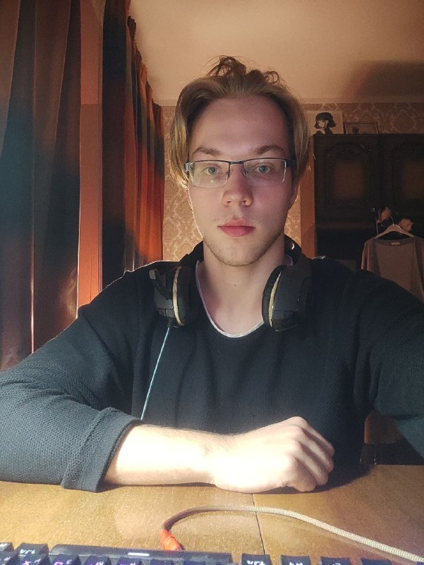

# Вводная часть

## Актуальность

Pass остается актуальным инструментом благодаря своей простоте, безопасности и интеграции с Unix-экосистемой. Он идеально подходит для пользователей, которые ценят локальное хранение данных, открытый исходный код и гибкость в управлении паролями. В условиях растущих угроз кибербезопасности pass предоставляет надежное решение для защиты учетных данных.

## Объект и предмет исследования

Объект исследования - Менеджер паролей pass как инструмент для управления паролями

Предмет исследования - Принципы работы - Функциональные возможности - Безопасность - Практическое применение

Четкое определение объекта и предмета исследования позволяет сосредоточиться на ключевых аспектах темы и провести глубокий анализ менеджера паролей pass.

## Цели и задачи

Цель установки менеджера паролей — обеспечить безопасное, удобное и эффективное управление учетными данными. Менеджер паролей помогает: - Создавать и использовать сложные уникальные пароли. - Защищать данные от утечек и атак. - Упрощать процесс входа на сайты и в приложения. - Организовывать и синхронизировать пароли между устройствами.

## Установка менеджера паролей pass

- Установка менеджера паролей `sudo dnf install pass pass-otp`, `sudo dnf install gopass`

## Настройка

- Инициализация хранилища, командой `pass init <gpg-id>`
- Создание структуры git `pass git init`
- Синхронизация `pass git pull`, `pass git push`
- Проверка статуса синхронизации `pass git status`

## Сохранение пароля

- Добавил новый пароль `pass insert [OPTIONAL DIR]/[FILENAME]`
- Отобразил пароль для указанного имени файла `pass [OPTIONAL DIR]/[FILENAME]`
- Заменил существующий пароль `pass generate --in-place FILENAME`

## Дополнительное программное обеспечение

Установил дополнительное программное обеспечение: sudo dnf -y install  
dunst  
fontawesome-fonts  
powerline-fonts  
light  
fuzzel  
swaylock  
kitty  
waybar swaybg  
wl-clipboard  
mpv  
grim  
slurp

## Дополнительное программное обеспечение

Установил шрифты: `sudo dnf copr enable peterwu/iosevka` `sudo dnf search iosevka` `sudo dnf install iosevka-fonts iosevka-aile-fonts iosevka-curly-fonts iosevka-slab-fonts iosevka-etoile-fonts iosevka-term-fonts`

## Установка

- Установка бинарного файла `sh -c "$(wget -qO- chezmoi.io/get)"`

## Создание собственного репозитория с помощью утилит

Создал репозиторий на основе шаблона

## Подключение репозитория к своей системе

- Инициализировал chezmoi с моим репозиторием `chezmoi init git@github.com:<username>/dotfiles.git`
- Проверил внесённые изменения `chezmoi diff`

## Ежедневные операции c chezmoi

- Включил функцию автоматической фиксации и отправке изменений в репозиторий: [git] autoCommit = true autoPush = true

# Результаты

**pass** — это мощный и гибкий менеджер паролей, который сочетает в себе простоту использования, высокий уровень безопасности и интеграцию с Unix-экосистемой. Он идеально подходит для пользователей, которые предпочитают консольные инструменты и хотят иметь полный контроль над своими данными. Благодаря использованию GPG и Git, **pass** обеспечивает надежное шифрование и удобную синхронизацию паролей между устройствами.